# Analyse des données de consommations d’énergie en Inde

# Environnement de travail

```r
library(tidyverse)
library(ggplot2)
library(readxl)
library(tidyr)
library(fda)
```

# Notre base de données

Notre étude porte sur l’analyse de la consommation d’énergie dans les 33 Etats d’Inde. Il est à noter que l’Inde est le troisième producteur et le troisième consommateur d’électricité au monde.

## Importation des données

Dans un premier temps, nous allons importer les données.

```r
data <- read.csv("long_data_2.csv", stringsAsFactors = T,sep = ";")

colnames(data) <- c("Etat", "Regions", "latitude", "longitude", "Date", "Consommation")
data <- data[,-c(3,4)]
summary(data)
```

```
                Etat       Regions                  Date        Consommation
 Andhra Pradesh   :  498   ER :2490   01/01/2020 00:00:   33   Min.   :  0.3
 Arunachal Pradesh:  498   NER:3486   01/02/2020 00:00:   33   1st Qu.:  6.7
 Assam            :  498   NR :4482   01/03/2020 00:00:   33   Median : 64.5
 Bihar            :  498   SR :2988   01/04/2020 00:00:   33   Mean   :103.1
 Chandigarh       :  498   WR :2988   01/05/2020 00:00:   33   3rd Qu.:174.0
 Chhattisgarh     :  498              01/06/2020 00:00:   33   Max.   :522.1
 (Other)          :13446              (Other)         :16236
```

```r
# View(data)
```

Grâce à ce résumé statistique, nous pouvons voir que les valeurs de nos données de consommation d’énergie sont assez étendues : elles sont comprises entre 0.3 et 522.1 Méga Units.

```r
data$Etat[which.max(data$Consommation)]
```

```
[1] Maharashtra
33 Levels: Andhra Pradesh Arunachal Pradesh Assam Bihar Chandigarh Chhattisgarh Delhi DNH Goa ... West Bengal
```

```r
data$Etat[which.min(data$Consommation)]
```

```
[1] Sikkim
33 Levels: Andhra Pradesh Arunachal Pradesh Assam Bihar Chandigarh Chhattisgarh Delhi DNH Goa ... West Bengal
```

En effet, certaines valeurs journalières sont très faibles (inférieures à 1) alors que d’autres sont 500 fois plus élevées. Par exemple, le Maharashtra qui présente certaines valeurs très importantes en opposition avec le Sikkim.

Concernant notre base de données, elle décrit la consommation d’énergie dans **33 Etats** d’Inde entre 2019 et 2020.  
Nous avons 16 434 lignes, soit **498 points de mesure** par pays (498*33). Les données sont journalières, exprimées en Mega Units.

```r
dim(data)
```

```
[1] 16434     4
```

## Choix de la période étudiée

Nous allons transformer notre variable Date au format date pour poursuivre l’étude correctement.

```r
data$Date <- as.Date(data$Date, format = "%d/%m/%Y %H:%M")
str(data) # Vérification
```

```
'data.frame':   16434 obs. of  4 variables:
 $ Etat        : Factor w/ 33 levels "Andhra Pradesh",..: 25 11 26 7 31 32 12 13 5 6 ...
 $ Regions     : Factor w/ 5 levels "ER","NER","NR",..: 3 3 3 3 3 3 3 3 3 5 ...
 $ Date        : Date, format: "2019-01-02" "2019-01-02" "2019-01-02" ...
 $ Consommation: num  119.9 130.3 234.1 85.8 313.9 ...
```

Pour simplifier notre analyse, nous allons nous concentrer seulement sur l’année 2019 :

```r
data <- data |>
  filter(Date <= as.Date("2020-01-02"))
```

On vérifie à présent que les données que l’on va analyser correspondent bien à la période choisie.

```r
min(data$Date)
max(data$Date)
```

[output not shown]

## Normalisation des données

Au départ, nous avons voulu normaliser les données par le nombre d’habitants de chaque Etat pour que les consommations aient le même impact dans notre étude. Cependant, cette méthode s’est révélée problématique car nous avons obtenu des valeurs très proches de zéro, ce qui aurait compliqué les calculs.

Nous avons donc choisi de réduire les données de consommation, en soustrayant la moyenne, pour continuer notre analyse avec données moins disproportionnées.

```r
moyenne_par_etat <- tapply(data$Consommation, data$Etat, mean)

normalized_energy <- data
for(i in 1:nrow(normalized_energy)){
  normalized_energy$Consommation[i] <- normalized_energy$Consommation[i] - moyenne_par_etat[normalized_energy$Etat[i]]
}
```

Suite à cette normailisation, nous pouvons observer une diminution importante des valeurs. Mais nous obtenons des valeurs de consommations négatives, ce qui pose problème pour l’interprétation de nos analyses. Nous allons donc travailler avec les valeurs initiales.

## Représentations graphiques

Nous allons tout d’abord représenter simplement nos données pour pouvoir faire ressortir les informations importantes.

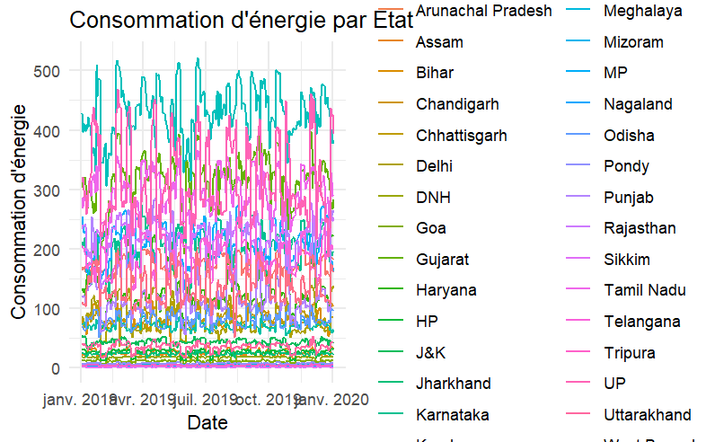

[figure not shown]

```r
ggplot(data, aes(x = Date, y = Consommation, color = Etat)) +
  geom_line() +
  labs(x = "Date", y = "Consommation d'énergie", title = "Consommation d'énergie par Etat") +
  theme_minimal()
```

Ce graphique nous montre que nos données sont très irrégulières.

Pour que les informations soient plus lisibles, nous avons décidé de séparer en plusieurs parties nos données. Nous avons fixé des seuils par rapport à la moyenne de consommations des Etats pour réaliser ces graphiques.

On calcule d’abord la moyenne par Etat et on ajoute cette moyenne a un nouveau dataframe :

```r
moyenne_par_etat <- tapply(data$Consommation, data$Etat, mean)
moyenne_par_etat <- data.frame(Etat = names(moyenne_par_etat), Moyenne = moyenne_par_etat)

data_complete <- merge(data,moyenne_par_etat, by = "Etat")
head(data_complete)
```

[output not shown]

On sépare les données en 3 catégories :

```r
data_inf <- data_complete |>
  filter(Moyenne <= 50)
# data_inf

data_moy <- data_complete |>
  filter(Moyenne > 50 & Moyenne < 200)
# data_moy

data_sup <- data_complete |>
  filter(Moyenne >= 200)
# data_sup
```

```r
ggplot(data_inf, aes(x = Date, y = Consommation, color = Etat)) +
  geom_line() +
  labs(x = "Date", y = "Consommation d'énergie", title = "Consommation d'énergie par Etat", subtitle = "Etats consommant moins de 50 Mega Units en moyenne") +
  theme_minimal()

ggplot(data_moy, aes(x = Date, y = Consommation, color = Etat)) +
  geom_line() +
  labs(x = "Date", y = "Consommation d'énergie", title = "Consommation d'énergie par Etat", subtitle = "Etats consommant entre 50 et 200 Mega Units en moyenne") +
  theme_minimal()

ggplot(data_sup, aes(x = Date, y = Consommation, color = Etat)) +
  geom_line() +
  labs(x = "Date", y = "Consommation d'énergie", title = "Consommation d'énergie par Etat", subtitle = "Etats consommant plus de 200 Mega Units en moyenne") +
  theme_minimal()
```

[output not shown]

Pour la plupart des Etats, leur consommation varie beaucoup tout au long de l’année et en quelques jours leur consommation peut doubler ou bien diminuer subitement.

Cependant certains Etats comme le Tripura possède une consommation très faible, et peu de variations dans son signal sont observées :

```r
data |>
  filter(Etat=="Tripura") |>
  ggplot(aes(x = Date, y = Consommation)) +
  geom_line() +
  labs(x = "Date", y = "Consommation d'énergie", title = "Consommation d'énergie du Tripura") +
  theme_minimal()
```

[output not shown]

```r
min(data$Consommation[data$Etat=="Tripura"])
max(data$Consommation[data$Etat=="Tripura"])
```

[output not shown]

A l’opposition du Punjab qui lui possède une très grande variation dans sa consommation :

```r
min(data$Consommation[data$Etat=="Punjab"])
max(data$Consommation[data$Etat=="Punjab"])
```

[output not shown]

Tableau des moyennes de consommation par Etat

```r
knitr::kable(tapply(data$Consommation, data$Etat, mean),
             "simple",
             caption = "Tableau des moyennes des consommation par Etat",
             col.names = "Moyenne",
             longtable = TRUE, width = "100%")
```

Tableau des moyennes des consommation par Etat

|  | Moyenne |
| --- | --- |
| Andhra Pradesh | 175.891573 |
| Arunachal Pradesh | 2.108146 |
| Assam | 25.156601 |
| Bihar | 83.878652 |
| Chandigarh | 4.132584 |
| Chhattisgarh | 84.220646 |
| Delhi | 82.659831 |
| DNH | 16.415590 |
| Goa | 11.183427 |
| Gujarat | 321.564747 |
| Haryana | 137.518258 |
| HP | 26.582303 |
| J&K | 44.331180 |
| Jharkhand | 23.998596 |
| Karnataka | 203.602247 |
| Kerala | 71.824298 |
| Maharashtra | 431.561517 |
| Manipur | 2.494101 |
| Meghalaya | 5.635674 |
| Mizoram | 1.712500 |
| MP | 208.722331 |
| Nagaland | 2.167416 |
| Odisha | 80.974438 |
| Pondy | 7.407865 |
| Punjab | 139.669522 |
| Rajasthan | 218.367977 |
| Sikkim | 1.296348 |
| Tamil Nadu | 297.655758 |
| Telangana | 188.360534 |
| Tripura | 4.145084 |
| UP | 314.962781 |
| Uttarakhand | 36.104494 |
| West Bengal | 139.527107 |

Représentation selon la région

L’Inde est divisée en 5 regions : le Nord (NR), Nord-Est (NER), le Sud (SR), l’Est (ER) et l’Ouest (WR) Nous allons tracer les consommations en fonction des régions (une couleur par région)./ De la même manière que les représentations précédentes, nous ne pouvons représenter les régions sur le même graphique. Sans diviser la représentation, il est difficile de bien observer les différences entre les régions.

Nous décidons donc de représenter une région par graphique :

```r
data |>
  filter(Regions=="ER") |>
  ggplot(aes(x = Date, y = Consommation,color = Etat)) +
  geom_line() +
  labs(x = "Date", y = "Consommation d'énergie", title = "Consommation d'énergie pour les Etats de l'Est de l'Inde") +
  theme_minimal()

data |>
  filter(Regions=="NER") |>
  ggplot(aes(x = Date, y = Consommation,color = Etat)) +
  geom_line() +
  labs(x = "Date", y = "Consommation d'énergie", title = "Consommation d'énergie pour les Etats du Nord Est de l'Inde") +
  theme_minimal()

data |>
  filter(Regions=="NR") |>
  ggplot(aes(x = Date, y = Consommation,color = Etat)) +
  geom_line() +
  labs(x = "Date", y = "Consommation d'énergie", title = "Consommation d'énergie pour les Etats du Nord de l'Inde") +
  theme_minimal()

data |>
  filter(Regions=="SR") |>
  ggplot(aes(x = Date, y = Consommation,color = Etat)) +
  geom_line() +
  labs(x = "Date", y = "Consommation d'énergie", title = "Consommation d'énergie pour les Etats du Sud de l'Inde") +
  theme_minimal()

data |>
  filter(Regions=="WR") |>
  ggplot(aes(x = Date, y = Consommation,color = Etat)) +
  geom_line() +
  labs(x = "Date", y = "Consommation d'énergie", title = "Consommation d'énergie pour les Etats de l'Ouest de l'Inde") +
  theme_minimal()
```

[output not shown]

Il serait intéressant de consulter l’avis d’un économiste ou politicien pour analyser et comprendre ces grandes disparités au sein des régions de l’Inde.

Nous construisons le tableau des moyennes de consommation par région :

```r
knitr::kable(tapply(data$Consommation, data$Regions, mean),
             "simple", col.names = "moyenne",
             caption = "Tableau des moyennes des consommation d'énergie par région")
```

[output not shown]